# Introduction to proteomics data analysis - MaxQuant Data Dependent Acquisition spike-in study

## 3.2 Data Processing

We now proceed to the data processing tab. The data processing tab already contains some pre-filled in options for filtering and data aggregation as we indicated that we imported data from DIA-NN software.

[figure not shown]

Figure 7. Data Processing 1

[figure not shown]

Figure 6. Data Processing 2

1. First we can restore the QFeatures object from import. This is something that we always have to do if we change the data processing settings and want to redo the data processing.
2. We can convert zeros to NA. This is important. Many softwares encode missing data with 0 intensity. If we want to address missingness and/or want to log-transfrom the data we have to convert the zeros to NA. You can hit the test button to test this setting.
3. We filter the data. We can add filters to the data based on the columns that contain information on the imported quant features. For DIA-NN, Spectronaut and MaxQuant we already provide sensible defaults. E.g.
   - Precursor.Id != ’’: we remove features for which the precursor was not set
   - Decoy == 0: we keep precursors that map to target sequences (decoys are indicated with 1)
   - Proteotypic == 1: we only keep precursors that are proteotypic (uniquely map to a single protein)
   - Q.Value <= 0.01: we keep features for which the Q-Value for identification is below an 1% FDR threshold.
   - PG.Q.Value <= 0.01: we keep features for which the protein group level Q-Value for identification is below an 1% FDR threshold
   - Lib.Q.Value <= 0.01: we keep features that were identified by matching between runs if their Q-Value for identification is below an 1% FDR threshold
   - Lib.PG.Q.Value <= 0.01: we keep features that were identified by matching between runs if their protein group level Q-Value for identification is below an 1% FDR threshold
   - Users can add additional filtering criteria.
- For maxQuant this for instance becomes
  - Proteins != ’’: we remove precursors that have not been mapped to a protein (!= –> is not equal to)
  - Reverse != ‘+’: we remove precursors that are matched to decoys sequences
  - Contaminants != ‘+’ or Potential.contaminant != ‘+’: we remove precursors are matched to contaminants (variable name for contaminants depends on MaxQuant version and is automatically detected).
4. Join assays: DIA-NN parquet files are in long format, then each run is stored in a different set. The sets can be joined so that we have all data for all samples/runs in the same set. By default we join the sets by using the Precursor.Id column. The joined set is by default stored as the set named `quants`. Users however can change this name.
5. Filter missing values: we can only estimate precursor or peptide characteristics if we have observed them in multiple samples. Here we will set this . If you have launched the previous test buttons, you will also see the number of features that were observed in 1, 2, 3, … samples. Here we will set the minimum number observations at `3`.
6. Log-transformation. Intensities quantified with MS are typically heteroscedastic (variance increase with the mean) and log-transformation is known to stabilise this. So by default we contact log-tranformation. Note, that you can switch this off if the data were already log-transformed.
7. Normalisation. By default we conduct `Median of Ratios normalisation`, which corrects for differences in loading between runs, as well as for differences in composition. If you use internal normalisation in DIA-NN, e.g. by starting from `Precursor.Normalised` intensities you can also put the normalisation method on `None`.
8. Aggregation. The data are often at the precursor, PSM or peptide level. However we want typically want to conduct the differential analysis at the protein level. So we first aggregate the data. We typically use a method that does the aggregation while accounting for the feature characteristics. `MaxLFQ` is a popular choice as `Method` for aggregation. The implementation in R is rather slow, so for large datasets we advice `medianPolish`. If the data are already summarized or if you would like to do inference at the precursor or peptide level you can omit the Aggregation by selecting `None`. Note that we also have to indicate the variable that contains information of features that belong to the same protein. For DIA-NN we set this `Aggregation column` to `Protein.Group` by default. We can again select the `Name` of the assay, which is by default set at `proteins`. Note, that we can also adopt an `N-peptides rule`. If we set it higher than 1, we will require at least #n peptides to be identified for each summarised protein quantity otherwise the protein quantity is set at NA.
9. The last step is again filtering missing values post-aggregation. Here, we want to do a two group comparison, so we would need to have at least 4 protein level summaries to be able to compare two groups.

# 4 Quality control

We can now perform quality control of all the assays in the quality control tab. By default the first Assay is selected.

*It is important to wait until the data is loaded, before selecting/changing the assay otherwise the app can crash*

1. Here we will select the `quants_log` assay first, which are the filtered, log2-transformed precursor-level quantities.

We will color the plots according to the `condition`.

Note, that we get plots for both all features and the common features, i.e. features observed in each sample. Both plots show that the data need normalisation.

[figure not shown]

Figure 7. QC 1

[figure not shown]

Figure 8. QC 2

2. We now change the assay to `quants_norm` which are the filtered, log2-transformed and normalised precursor-level quantities. We observe that upon medianOfRatio normalisation, the distributions of both all features and the common features are comparable.

We also observe that the number of identified features per sample is also comparable.

We now perform Dimensionality reduction. We have to hit the `Run` button first. Note, that we have to rerun the Run button each time we change the assay. We see that the samples align somewhat according to the spikein condition.

[figure not shown]

Figure 9. QC 3

[figure not shown]

Figure 10. QC 34

3. We now change the assay to `proteins_filter_na` which are the filtered, log2-transformed, normalised and aggregated protein-level quantities.  
   We observe that also at the protein level the distribution of all features and the common features nicely align. At the protein level the identifications per sample are also very comparable. If we rehit the `Run` button we also observe that the samples are better separated upon dimensionality reduction when starting from protein level summaries.

[figure not shown]

Figure 11. QC 5

[figure not shown]

Figure 12. QC 6

# 5 Data Modeling

We will now model the data at the protein level.

1. We select the `protein_filter_na` set in `Select Assay`
2. We can model the sources of variation in the data using the variables in the annotation file. In this experimental design, we can model a single source of variation: spike-in concentration8. All remaining sources of variability, e.g. pipetting errors, MS run to run variability, etc will be lumped in the residual variability (error term). We can do this by using the variable condition. We have to define a model formula for that. The model always starts with `~`. So we type `~ condition` in the `Design formula`. Note, that you can copy and paste the variable names that are listed below Build Model to avoid typing errors.
3. We can set the option `Ridge regression for fixed effects`, which is by default set at `No`. Ridge regression can stabilize the estimation of the model parameters. However, we only advice that for designs with many model parameters.
4. We can set the option `Robust regression for fixed effects`, which is by default set at `Yes`. This robustifies the parameter estimation against outliers, which often occur in proteomics data.
5. As soon as a valid model is formulated you will see that a plot appears under Visualize Design. The plot shows the different means that are modeled.
6. *Do not forget to hit the `Fit Model!`* button to fit the model for each feature of the selected assay.

[figure not shown]

Figure 13. Model 1

[figure not shown]

Figure 14. Model 2

# 6 Inference tab

We can now conduct formal hypothesis tests for each feature. We do this in the `inference tab`.

We can `add contrasts`, which define the null hypothesis for a research question using linear combinations of model parameters.

In our case we would like to prioritise proteins that are differentially abundant between conditions, i.e. between ratio4 vs ratio2, ratio8 vs ratio2, and ratio 8 vs ratio 4.

Since we model the data at the log scale, we know that the difference in mean between ratio4 and ratio2 is a $\log_2 FC$. I.e. $\log_2 FC^{4-2}= \mu_4 - \mu_2 =$ (intercept) + conditionratio04 - (intercept) = conditionratio04. So `conditionratio04 = 0` formulates the null hypothesis that a feature is not differentially abundant (DA) between condition 4 and condition 2.

1. So we type `conditionratio04 = 0` in `Add contrast` and we push the `Add` button. We see that the contrast is added.
2. We click `Test all contrasts`

[figure not shown]

Figure 15. Inference1

[figure not shown]

Figure 16. Inference2

A volcano plot for the contrast appears along with a table with the DA features. And a boxplot.

[figure not shown]

Figure 17. Inference3

3. Note that you also can set the `Significance level` and can untick significant features in table, so as to see all features.
4. Here, we are interested in testing multiple contrasts as we have to conduct 3 pairwise tests to assess all pairwise comparisons between the treatments. We could do this by defining the two additional contrasts and adding them. However, for factors that are additive in the model, we can also select the factor variable to `Add all pairwise contrasts for a factor variable` and click `Add all pairwise contrasts`. Note, that we first have to remove the contrast that we already defined, i.e. push the `clear all contrasts` button to avoid to add two times the same contrast. Note, that after hitting the `Test all contrasts` you can now explore the three contrasts.

[figure not shown]

Figure 18. Inference4

[figure not shown]

Figure 19. Inference5

# 7 Report tab

You can download a report for your data analysis.

1. In the report tab you can give your report a name, e.g. staes248-spikein, by default it is named `project`.
2. Then hit the Generate full report bundle
3. A screen will pop up and you will ask to choose a location to store the zip bundle. Note, that a timestamp is automatically added to your report name.

If you unzip the bundle you will see that it contains:

1. Input search results
2. Annotation file
3. Rmarkdown file for the data processing.
4. Rmarkdown file for the modeling and inference.
5. A table inference.tsv contain the results for all contrasts.

So the entire data analysis can be documented in a fully reproducible way.

Note, that the scripts can also help you to learn how to setup and automate msqrob2 data analysis workflows in a reproducible way using scripts. Note, that more info in modeling with msqrob2 can also be found in our online e-book [msqrob2book](https://statomics.github.io/msqrob2book/).

[figure not shown]

Figure 20. Report 1

[figure not shown]

Figure 21. Report 2

[figure not shown]

Figure 22. Report 3

# 8 Explore with altSEE tab

You can also explore the results interactively.

1. Select the `Main experiment` (that is by default the assay selected for modeling)
2. Select the `Alt experiment` the is by default the first assay in the QFeatures object that differs from the `Main experiment` define in 1. Here we will select `quants_norm`
3. Optionally you can select the variable that will be used in the X-axis of the plots when starting the app (they can be changed in the app). Here, we choose the variable `sampleId`
4. Optionally you can select the column that can link features between the Main experiment and the Alt experiment. Here, that is the `Protein.Group` that was used for aggregation.
5. We hit the Launch iSEE button and a novel app will be prepared. That typically takes a while.
6. Once you see `Ready. Refresh the iSEE tab after re-launching, you can click the link and that will open the iSEE app in a new browser window. Again this can take a while.

[figure not shown]

Figure 23. AltSee 1

[figure not shown]

Figure 24. altSEE 2

Once the iSEE app is open, we can interactively explore the data.

1. The top panels show the reduced dimension plots for both the main and alt experiment. Note, that you can change the alt experiment, under data parameters, if you want to explore other assays.

[figure not shown]

Figure 25. AltSee 0

2. The second panels show volcano plots. Note, that we do not have a volcano plot for the altExp because we did not fit models at the precursor level. We can also select points in the volcano plot. These will then be selected in the table below, which is linked to the volcanoplot.

[figure not shown]

Figure 26. altSEE 3

3. In the table now all significant hits are shown that we selected in the volcanoplot. We can select a hit in the table, but we first order the table according to the p.value. We now select the top hit.

[figure not shown]

Figure 27. altSEE 4

4. This hit will now be visualised in the bottom panels. The plots show the results for each feature that maps to the protein in the left data table (when starting the app, as a user you can change that). Features are connected with a line, in the default visualisation.

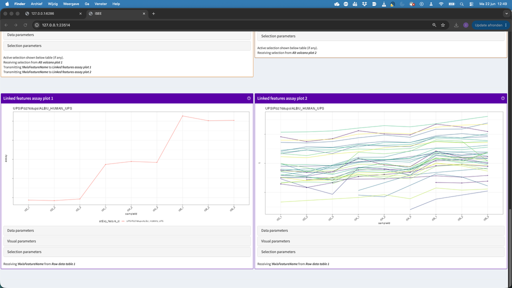

Figure 28. altSEE 5

5. We can also change the plot layout, e.g. to show violin plots for the precursors. E.g click data parameters > Plot type > automatic. For factor variables in the x axis, by default we get a violin plot.  
   You can also change the colors, split the panels, etc. When you play with the `Visualisation parameters`. You can click the `Question mark` next to the panel to get a panel tour.

[figure not shown]

Figure 29. altSEE 6